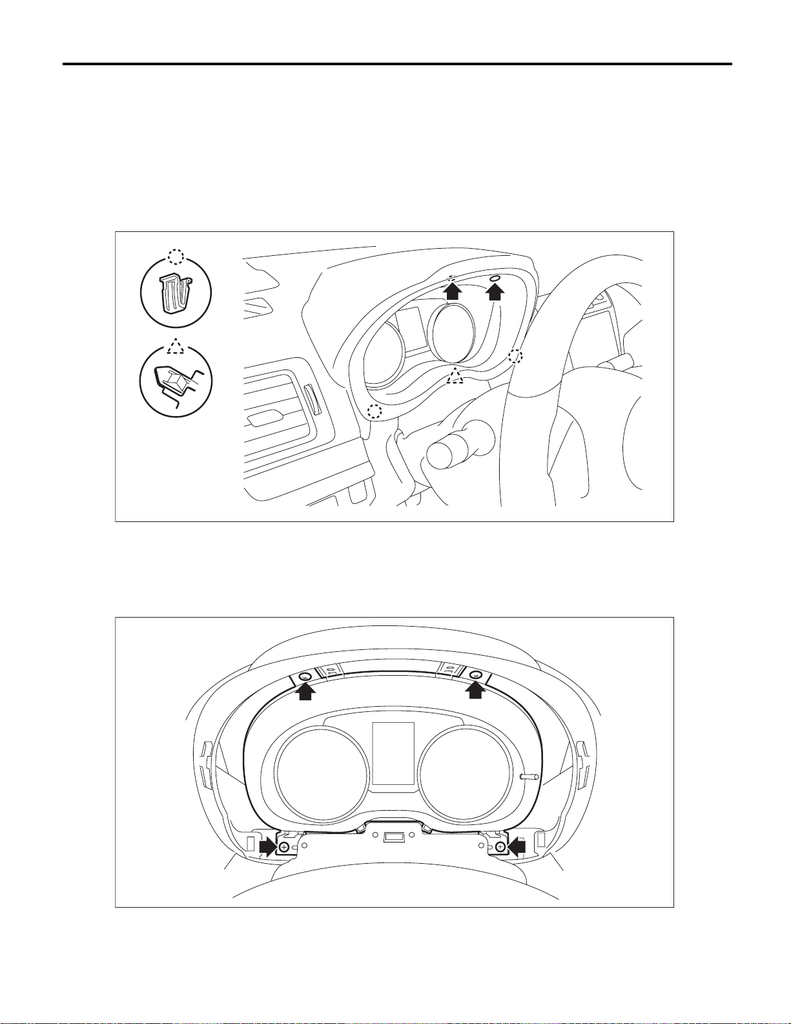

IDI-13

Combination Meter

INSTRUMENTATION/DRIVER INFO

5. Combination Meter

A: REMOVAL

1) Disconnect the ground cable from battery. <Ref. to NT-5, BATTERY, NOTE, Note.>

NOTE:

For models other than STI model, disconnect the ground terminal from battery sensor.

3) Release the screws, clips and claws, and remove the visor - combination meter.

4) Remove the combination meter assembly.

CAUTION:

• Be careful not to damage the meter or instrument panel.

• Pay particular attention to avoid damaging the meter glass.

(1) Remove the screws.

IDI00763

IDI00764

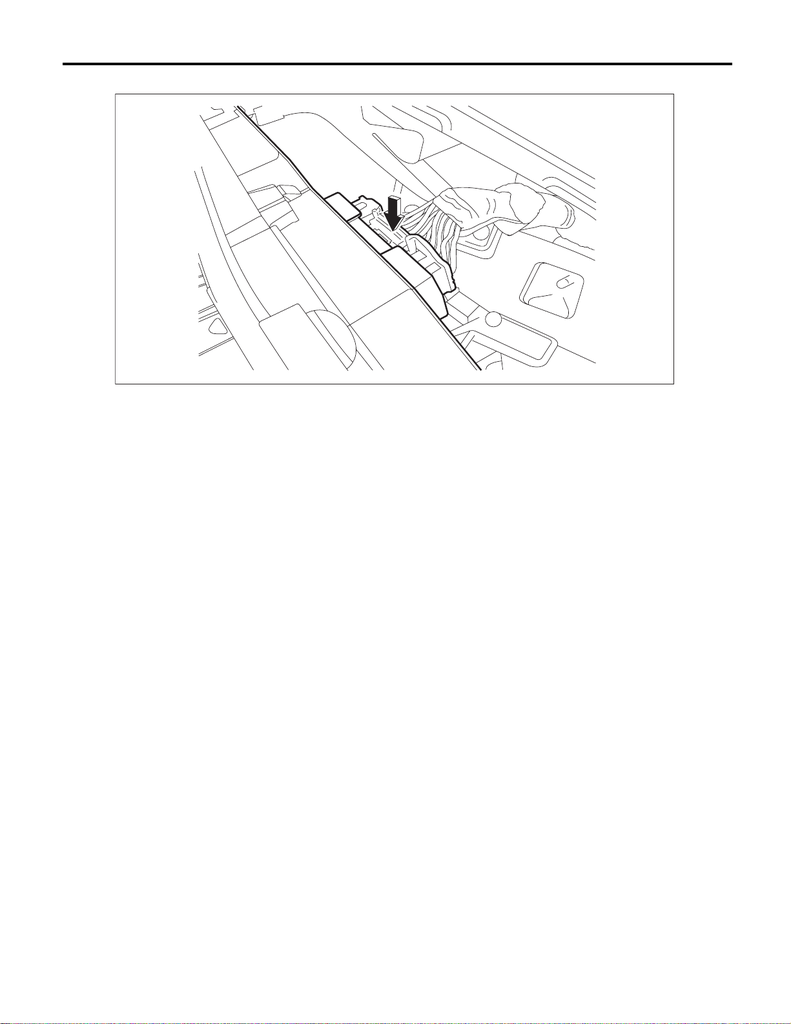

IDI-14

Combination Meter

INSTRUMENTATION/DRIVER INFO

(2) Pull the combination meter assembly toward you and disconnect the connector.

B: INSTALLATION

CAUTION:

• Make sure the electrical connector is connected securely.

• Make sure that each meter operates normally.

• When the combination meter assembly has been replaced, be sure to perform the following oper-

ations.

– For keyless entry model except for C0, be sure to perform the registration of immobilizer. For the

relevant procedures, refer to the “REGISTRATION MANUAL FOR IMMOBILIZER”.

– Be sure to reset the ODO fuel economy value of the multi-function display (MFD). <Ref. to IDI-12,

ODO FUEL ECONOMY VALUE RESET, OPERATION, Multi-function Display (MFD) System.>

1) Install the combination meter assembly.

2) Install the visor - combination meter.

3) Connect the battery ground terminal. <Ref. to NT-5, BATTERY, NOTE, Note.>

NOTE:

For models other than STI model, connect the ground terminal to battery sensor.

IDI00291

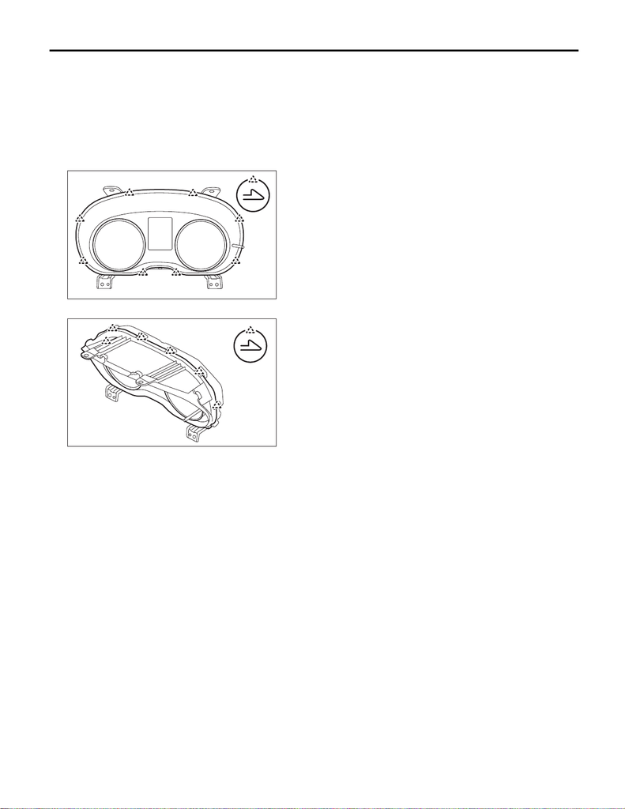

IDI-15

Combination Meter

INSTRUMENTATION/DRIVER INFO

C: DISASSEMBLY

CAUTION:

• Use gloves to avoid damage and getting fingerprints on the glass surface and meter surfaces.

• Be careful not to apply excessive force to the trip knob.

• Be sure not to touch the meter indicator needle.

• Because LEDs are used for all of warning lights and indicator lights, they are not removable from

the meter - main assembly.

1) Release the claws, and then remove the glass - combination meter.

2) Release the claws, and then remove the visor - combination meter.

D: ASSEMBLY

1) Install the visor - combination meter.

2) Install the glass - combination meter.

IDI00765

IDI00766